# Pandas

## Correlation

Correlation summarizes the relationship between two variables

### How to assess the correlation ?

- **Option 1**: Visualize data (scatter plot)
- **Option 2**: Correlation coefficient

### Option 1: Visualization

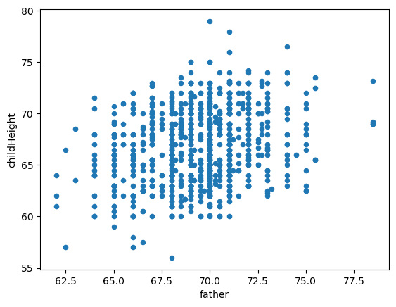

```python
df.plot.scatter(x='father', y='childHeight');
```

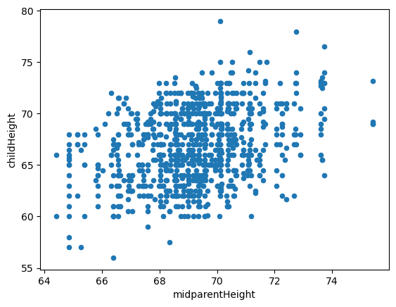

```python
#df.plot.scatter(x='mother', y='childHeight');
df.plot.scatter(x='midparentHeight', y='childHeight');
```

[figure not shown]

### Option 2: Correlation Coefficient

- A correlation coefficient quite close to 0 implies little or no relationship between the two variables.
- A correlation coefficient close to +1 means a positive relationship between the two variables, with increases in one of the variables being associated with increases in the other variable.
- A correlation coefficient close to -1 indicates a negative relationship between two variables, with an increase in one of the variables being associated with a decrease in the other variable.

[figure not shown]

```python
df.corr()
```

|  | father | mother | midparentHeight | children | childNum | childHeight |
| --- | --- | --- | --- | --- | --- | --- |
| father | 1.000000 | 0.060366 | 0.728439 | -0.151333 | -0.087446 | 0.266039 |
| mother | 0.060366 | 1.000000 | 0.727834 | -0.033582 | -0.019405 | 0.201322 |
| midparentHeight | 0.728439 | 0.727834 | 1.000000 | -0.127016 | -0.073395 | 0.320950 |
| children | -0.151333 | -0.033582 | -0.127016 | 1.000000 | 0.577838 | -0.126720 |
| childNum | -0.087446 | -0.019405 | -0.073395 | 0.577838 | 1.000000 | -0.625026 |
| childHeight | 0.266039 | 0.201322 | 0.320950 | -0.126720 | -0.625026 | 1.000000 |

### Explore categorical variables

```python
# Get unique values
df['children'].unique()
```

```
array([ 4,  2,  5,  6,  1,  3,  8,  9,  7, 11, 10, 15])
```

```python
# value counts
df['children'].value_counts()
```

```
5     140
8     136
4     124
7     119
6     108
3      66
9      63
2      46
11     44
10     40
1      33
15     15
Name: children, dtype: int64
```

## Chapter 6: Data Loading

[figure not shown]

### Arguments categories:

Data loading functions has a long list of optional arguments

for example: *pandas.read_csv* has around 50 argument

[figure not shown]

*type inference*: That means you don’t necessarily have to specify which columns are numeric, integer, Boolean, or string

### Loading and writing CSV files

```python
# Read CSV file
df = pd.read_csv("galton.csv")
df
```

|  | family | father | mother | midparentHeight | children | childNum | gender | childHeight |
| --- | --- | --- | --- | --- | --- | --- | --- | --- |
| 0 | 1 | 78.5 | 67.0 | 75.43 | 4 | 1 | male | 73.2 |
| 1 | 1 | 78.5 | 67.0 | 75.43 | 4 | 2 | female | 69.2 |
| 2 | 1 | 78.5 | 67.0 | 75.43 | 4 | 3 | female | 69.0 |
| 3 | 1 | 78.5 | 67.0 | 75.43 | 4 | 4 | female | 69.0 |
| 4 | 2 | 75.5 | 66.5 | 73.66 | 4 | 1 | male | 73.5 |
| ... | ... | ... | ... | ... | ... | ... | ... | ... |
| 929 | 203 | 62.0 | 66.0 | 66.64 | 3 | 1 | male | 64.0 |
| 930 | 203 | 62.0 | 66.0 | 66.64 | 3 | 2 | female | 62.0 |
| 931 | 203 | 62.0 | 66.0 | 66.64 | 3 | 3 | female | 61.0 |
| 932 | 204 | 62.5 | 63.0 | 65.27 | 2 | 1 | male | 66.5 |
| 933 | 204 | 62.5 | 63.0 | 65.27 | 2 | 2 | female | 57.0 |

934 rows × 8 columns

https://pandas.pydata.org/pandas-docs/stable/reference/api/pandas.read_csv.html

```python
# Define index
df2 = pd.read_csv("galton.csv", index_col = 'family')
df2.head()
```

| family | father | mother | midparentHeight | children | childNum | gender | childHeight |
| --- | --- | --- | --- | --- | --- | --- | --- |
| 1 | 78.5 | 67.0 | 75.43 | 4 | 1 | male | 73.2 |
| 1 | 78.5 | 67.0 | 75.43 | 4 | 2 | female | 69.2 |
| 1 | 78.5 | 67.0 | 75.43 | 4 | 3 | female | 69.0 |
| 1 | 78.5 | 67.0 | 75.43 | 4 | 4 | female | 69.0 |
| 2 | 75.5 | 66.5 | 73.66 | 4 | 1 | male | 73.5 |

```python
df2.iloc[0]
```

[output not shown]

```python
df2.loc[0]
```

[output not shown]

```python
# Define hierarchical index
df_3 = pd.read_csv("galton.csv", index_col = ['family', 'childNum'])
df_3
```

| family | childNum | father | mother | midparentHeight | children | gender | childHeight |
| --- | --- | --- | --- | --- | --- | --- | --- |
| 1 | 1 | 78.5 | 67.0 | 75.43 | 4 | male | 73.2 |
|  | 2 | 78.5 | 67.0 | 75.43 | 4 | female | 69.2 |
|  | 3 | 78.5 | 67.0 | 75.43 | 4 | female | 69.0 |
|  | 4 | 78.5 | 67.0 | 75.43 | 4 | female | 69.0 |
| 2 | 1 | 75.5 | 66.5 | 73.66 | 4 | male | 73.5 |
| ... | ... | ... | ... | ... | ... | ... | ... |
| 203 | 1 | 62.0 | 66.0 | 66.64 | 3 | male | 64.0 |
|  | 2 | 62.0 | 66.0 | 66.64 | 3 | female | 62.0 |
|  | 3 | 62.0 | 66.0 | 66.64 | 3 | female | 61.0 |
| 204 | 1 | 62.5 | 63.0 | 65.27 | 2 | male | 66.5 |
|  | 2 | 62.5 | 63.0 | 65.27 | 2 | female | 57.0 |

934 rows × 6 columns

```python
# Write csv file
df.to_csv('new path')
```

### Loading and writing Pickle (Binary) files

```python
# Save(Serialize) df as binary file
df.to_pickle("df.pickle")
```

```python
# Read dataframe from pickle file
pd.read_pickle('df.pickle')
```

|  | family | father | mother | midparentHeight | children | childNum | gender | childHeight |
| --- | --- | --- | --- | --- | --- | --- | --- | --- |
| 0 | 1 | 78.5 | 67.0 | 75.43 | 4 | 1 | male | 73.2 |
| 1 | 1 | 78.5 | 67.0 | 75.43 | 4 | 2 | female | 69.2 |
| 2 | 1 | 78.5 | 67.0 | 75.43 | 4 | 3 | female | 69.0 |
| 3 | 1 | 78.5 | 67.0 | 75.43 | 4 | 4 | female | 69.0 |
| 4 | 2 | 75.5 | 66.5 | 73.66 | 4 | 1 | male | 73.5 |
| ... | ... | ... | ... | ... | ... | ... | ... | ... |
| 929 | 203 | 62.0 | 66.0 | 66.64 | 3 | 1 | male | 64.0 |
| 930 | 203 | 62.0 | 66.0 | 66.64 | 3 | 2 | female | 62.0 |
| 931 | 203 | 62.0 | 66.0 | 66.64 | 3 | 3 | female | 61.0 |
| 932 | 204 | 62.5 | 63.0 | 65.27 | 2 | 1 | male | 66.5 |
| 933 | 204 | 62.5 | 63.0 | 65.27 | 2 | 2 | female | 57.0 |

934 rows × 8 columns

### Reading from MS Excel

```python
pd.read_excel("grocery.xlsx", sheet_name = 'prices')
```

|  | Item | Mawares | Abo Ahmad | Bravo | Karaz | Max mar | Shini | Baghdad | Gardens |
| --- | --- | --- | --- | --- | --- | --- | --- | --- | --- |
| 0 | Lemon | 2.3 | 2.0 | 3.0 | 3.0 | 3.5 | 2.7 | 3.1 | 4.0 |
| 1 | Tomato | 2.0 | 2.0 | 2.2 | 2.5 | 3.0 | 2.0 | 3.0 | 2.4 |
| 2 | Potato | 3.3 | 3.3 | 3.3 | 4.0 | 5.0 | 3.0 | 3.5 | 3.5 |
| 3 | Watermelon | 1.0 | 1.5 | 1.5 | 1.5 | 3.0 | 2.0 | 3.0 | 3.0 |
| 4 | Zucchini | 12.0 | 8.0 | 8.0 | 8.0 | 12.0 | 7.0 | 8.0 | 10.0 |
| 5 | Eggplant | 3.0 | 2.5 | 3.0 | 3.0 | 5.0 | 3.0 | 5.0 | 5.0 |
| 6 | Apple | 7.0 | 7.0 | 8.0 | 7.0 | 13.0 | 8.0 | 10.0 | 12.0 |
| 7 | Panana | 3.3 | 3.3 | 3.0 | 4.0 | 4.0 | 3.5 | 5.0 | 5.0 |

### Loading from web

```python
import requests
url = "https://dummyjson.com/products/2"
resp = requests.get(url)
data = resp.json()
data
```

```
{'id': 2,
 'title': 'iPhone X',
 'description': 'SIM-Free, Model A19211 6.5-inch Super Retina HD display with OLED technology A12 Bionic chip with ...',
 'price': 899,
 'discountPercentage': 17.94,
 'rating': 4.44,
 'stock': 34,
 'brand': 'Apple',
 'category': 'smartphones',
 'thumbnail': 'https://cdn.dummyjson.com/product-images/2/thumbnail.jpg',
 'images': ['https://cdn.dummyjson.com/product-images/2/1.jpg',
  'https://cdn.dummyjson.com/product-images/2/2.jpg',
  'https://cdn.dummyjson.com/product-images/2/3.jpg',
  'https://cdn.dummyjson.com/product-images/2/thumbnail.jpg']}
```

```python
pd.DataFrame(data)
```

|  | id | title | description | price | discountPercentage | rating | stock | brand | category | thumbnail | images |
| --- | --- | --- | --- | --- | --- | --- | --- | --- | --- | --- | --- |
| 0 | 2 | iPhone X | SIM-Free, Model A19211 6.5-inch Super Retina H... | 899 | 17.94 | 4.44 | 34 | Apple | smartphones | https://cdn.dummyjson.com/product-images/2/thu... | https://cdn.dummyjson.com/product-images/2/1.jpg |
| 1 | 2 | iPhone X | SIM-Free, Model A19211 6.5-inch Super Retina H... | 899 | 17.94 | 4.44 | 34 | Apple | smartphones | https://cdn.dummyjson.com/product-images/2/thu... | https://cdn.dummyjson.com/product-images/2/2.jpg |
| 2 | 2 | iPhone X | SIM-Free, Model A19211 6.5-inch Super Retina H... | 899 | 17.94 | 4.44 | 34 | Apple | smartphones | https://cdn.dummyjson.com/product-images/2/thu... | https://cdn.dummyjson.com/product-images/2/3.jpg |
| 3 | 2 | iPhone X | SIM-Free, Model A19211 6.5-inch Super Retina H... | 899 | 17.94 | 4.44 | 34 | Apple | smartphones | https://cdn.dummyjson.com/product-images/2/thu... | https://cdn.dummyjson.com/product-images/2/thu... |

[figure not shown]

## Assignment #4

Navigate Kaggle and select a data set that contains at least 5 features and have both categorical and numerical features.

1. With well-styled markdown cell, describe the data set and show the dictionary of the columns (for each column provide the name, data type, and description)
2. Load the data set to your notebook and answer the following questions:
   - What is the shape of the data?
   - Does it contain missing values?
   - Which features are numerical, and which are nominal, and which are ordinal ?
   - Select two numerical features and:
     - Show their descriptive statistics, add your interpretation on each feature
     - Does they have skweness? interpret
   - Select two categorical features and verify if the data is balanced between the categories of each feature
   - Based on your intuition, select two features that you think they could be correlated. Verify your assumption using both visualization and the correlation coefficient approaches
   - Are their features that can be used as index?
- Add your name and id in the top of the notebook
- Use generative AI to answer the relationship and representative questions
- replace=False/True
- Write the code in one cell and generate the interpretation out of the code
- Used statistical tests such as Shapiro to test normality
- Using cuz, and such terms in inerpretation